# STRING Functional-Association Network Across the Four Significant LR Lists

Do genes from independent cell-type-pair analyses share a real interaction/functional module?

Published

October 9, 2026

## 1 Overview

`04_KEGG_PathwayConvergence.qmd` asks whether genes from two different cell-type-pair analyses land on the same **curated KEGG pathway diagram**. That’s one specific, fairly narrow curated resource. This notebook asks the same underlying convergence question a different way: do genes from independent cell-type-pair analyses sit in the same **functional-association network module**, using STRING’s combined evidence (curated databases, experiments, co-expression, and text-mining, not just KEGG)?

```r
library(dplyr)
library(tibble)

if (!requireNamespace("STRINGdb", quietly = TRUE)) {
  if (!requireNamespace("BiocManager", quietly = TRUE)) install.packages("BiocManager")
  BiocManager::install("STRINGdb", update = FALSE, ask = FALSE)
}
library(STRINGdb)
```

## 2 Load the curated significant-LR gene list

Same source as `04_KEGG_PathwayConvergence.qmd`: `significant_lr_pairs.csv`, exported by `03c_crossModality_plots.qmd`’s “Export the curated (3-metric-agreement) significant LR pairs” section.

```r
split_complex <- function(x) stringr::str_split(x, "_")

out_dir <- file.path("output", "05_STRING_NetworkAnalysis")
dir.create(out_dir, recursive = TRUE, showWarnings = FALSE)

sig_pairs <- read.csv(file.path("output", "03c_crossModality_plots", "significant_lr_pairs.csv"), stringsAsFactors = FALSE) %>%
  distinct(spatial_pair, ligand_complex, receptor_complex)

lr_gene_sets <- purrr::pmap(sig_pairs, function(spatial_pair, ligand_complex, receptor_complex) {
  ligands   <- unlist(split_complex(ligand_complex))
  receptors <- unlist(split_complex(receptor_complex))
  tibble(
    spatial_pair = spatial_pair,
    gene = unique(c(ligands, receptors)),
    role = ifelse(unique(c(ligands, receptors)) %in% ligands, "ligand", "receptor")
  )
})

lr_genes_long <- bind_rows(lr_gene_sets) %>% distinct(spatial_pair, gene, role)
unique_genes  <- unique(lr_genes_long$gene)

lr_genes_long
```

| spatial_pair | gene | role |
| --- | --- | --- |
| Astrocyte-Vascular | Ptn | ligand |
| Astrocyte-Vascular | Sdc4 | receptor |
| Astrocyte-Vascular | Ptprs | receptor |
| Astrocyte-Vascular | Fgfr3 | ligand |
| Astrocyte-Vascular | Epha4 | receptor |
| Astrocyte-Vascular | Cxcl12 | ligand |
| Astrocyte-Vascular | Itgb1 | receptor |
| Astrocyte-Vascular | Mif | ligand |
| Astrocyte-Vascular | Ackr3 | receptor |
| Astrocyte-Vascular | Vtn | ligand |

[output cut: 59 more lines]

## 3 Build the STRING network and map genes to STRING IDs

Mouse NCBI taxonomy ID is `10090`. `score_threshold = 400` is STRING’s own “medium confidence” default; raise it (e.g. to `700`, “high confidence”) later to check whether clusters hold up on stronger evidence alone.

```r
string_db <- STRINGdb$new(
  version         = "12.0",
  species         = 10090,
  score_threshold = 400,
  input_directory = ""
)


map_genes_safe <- function(string_db, genes) {
  gene_df <- data.frame(gene = genes, stringsAsFactors = FALSE)
  rownames(gene_df) <- NULL

  tryCatch(
    string_db$map(gene_df, "gene", removeUnmappedRows = TRUE),
    error = function(e) {
      message("Bulk STRINGdb$map() failed (", conditionMessage(e), ") -- ",
              "falling back to mapping genes one at a time.")
      purrr::map_dfr(genes, function(g) {
        one <- data.frame(gene = g, stringsAsFactors = FALSE)
        tryCatch(
          string_db$map(one, "gene", removeUnmappedRows = TRUE, quiet = TRUE),
          error = function(e2) {
            message("  Dropping '", g, "' -- STRINGdb$map() errors on it individually (",
                    conditionMessage(e2), ")")
            NULL
          }
        )
      })
    }
  )
}

mapped <- map_genes_safe(string_db, unique_genes)

unmapped_genes <- setdiff(unique_genes, mapped$gene)
if (length(unmapped_genes) > 0) {
  message("No STRING mapping found for: ", paste(unmapped_genes, collapse = ", "),
          " -- coverage gap in STRING's identifier mapping, not evidence against real biology.")
}

mapped
```

|  | gene | STRING_id |
| --- | --- | --- |
| 1 | Ptn | 10090.ENSMUSP00000099073 |
| 2 | Sdc4 | 10090.ENSMUSP00000017153 |
| 3 | Ptprs | 10090.ENSMUSP00000064048 |
| 4 | Fgfr3 | 10090.ENSMUSP00000133064 |
| 5 | Epha4 | 10090.ENSMUSP00000027451 |
| 6 | Cxcl12 | 10090.ENSMUSP00000072800 |
| 7 | Itgb1 | 10090.ENSMUSP00000087457 |
| 8 | Mif | 10090.ENSMUSP00000041149 |
| 9 | Ackr3 | 10090.ENSMUSP00000069114 |
| 10 | Vtn | 10090.ENSMUSP00000017488 |

[output cut: 43 more lines]

## 4 Cluster the network (k = 4 k-means)

```r
n_clusters <- 4

interactions <- string_db$get_interactions(mapped$STRING_id)

score_col <- intersect(c("combined_score", "score"), names(interactions))[1]
if (is.na(score_col)) {
  stop("Couldn't find a combined-score column in string_db$get_interactions() output. ",
       "Columns present: ", paste(names(interactions), collapse = ", "),
       " -- check the STRINGdb version's return format and adjust score_col above.")
}

ids <- mapped$STRING_id

degree_tbl <- tibble(STRING_id = c(interactions$from, interactions$to)) %>%
  dplyr::filter(STRING_id %in% ids) %>%
  dplyr::count(STRING_id, name = "degree")

connected_ids <- intersect(ids, degree_tbl$STRING_id[degree_tbl$degree > 0])
isolated_ids  <- setdiff(ids, connected_ids)

isolated_genes <- mapped %>% dplyr::filter(STRING_id %in% isolated_ids) %>% dplyr::pull(gene)
if (length(isolated_genes) > 0) {
  message("Not clustered (no interaction edges to anything else in this gene set): ",
          paste(isolated_genes, collapse = ", "))
}

score_matrix <- matrix(0, nrow = length(connected_ids), ncol = length(connected_ids),
                        dimnames = list(connected_ids, connected_ids))

idx_from <- match(interactions$from, connected_ids)
idx_to   <- match(interactions$to, connected_ids)
valid    <- !is.na(idx_from) & !is.na(idx_to)

score_matrix[cbind(idx_from[valid], idx_to[valid])] <- interactions[[score_col]][valid]
score_matrix[cbind(idx_to[valid], idx_from[valid])] <- interactions[[score_col]][valid]

set.seed(1)
km <- kmeans(score_matrix, centers = n_clusters, nstart = 50)

cluster_df <- dplyr::bind_rows(
  tibble(STRING_id = connected_ids, cluster = km$cluster),
  tibble(STRING_id = isolated_ids, cluster = NA_integer_)
)

gene_cluster <- mapped %>%
  dplyr::select(gene, STRING_id) %>%
  inner_join(cluster_df, by = "STRING_id") %>%
  inner_join(lr_genes_long, by = "gene", relationship = "many-to-many")

gene_cluster %>% arrange(cluster, gene)
```

| gene | STRING_id | cluster | spatial_pair | role |
| --- | --- | --- | --- | --- |
| Bsg | 10090.ENSMUSP00000070751 | 1 | Vascular-Microglia | ligand |
| Cd47 | 10090.ENSMUSP00000099853 | 1 | Astrocyte-Vascular | receptor |
| Cd47 | 10090.ENSMUSP00000099853 | 1 | Vascular-Microglia | receptor |
| Itga9 | 10090.ENSMUSP00000044227 | 1 | Vascular-Microglia | receptor |
| Itgav | 10090.ENSMUSP00000028499 | 1 | Astrocyte-Vascular | receptor |
| Itgav | 10090.ENSMUSP00000028499 | 1 | Vascular-Microglia | receptor |
| Itgav | 10090.ENSMUSP00000028499 | 1 | OPC-Cajal.Retzius | receptor |
| Itgb1 | 10090.ENSMUSP00000087457 | 1 | Astrocyte-Vascular | receptor |
| Itgb1 | 10090.ENSMUSP00000087457 | 1 | Vascular-Microglia | receptor |
| Lrp1 | 10090.ENSMUSP00000044004 | 1 | Astrocyte-Vascular | receptor |

[output cut: 59 more lines]

## 5 Convergence: clusters hit by 2+ different cell-type-pair analyses

Same convergence framing as `04_KEGG_PathwayConvergence.qmd`’s `convergence_pathways` table, applied to STRING’s data-driven clusters instead of named KEGG pathways.

```r
string_convergence <- gene_cluster %>%
  dplyr::filter(!is.na(cluster)) %>%   # drop the "not clustered" (zero-edge) genes
  distinct(spatial_pair, cluster, gene) %>%
  group_by(cluster) %>%
  summarise(
    n_spatial_pairs_hitting_it = n_distinct(spatial_pair),
    n_distinct_genes           = n_distinct(gene),
    genes                      = paste(sort(unique(gene)), collapse = ", "),
    .groups = "drop"
  ) %>%
  arrange(desc(n_spatial_pairs_hitting_it), desc(n_distinct_genes))

string_convergence
```

| cluster | n_spatial_pairs_hitting_it | n_distinct_genes | genes |
| --- | --- | --- | --- |
| 2 | 4 | 28 | Ackr3, Adam10, Aplp1, Aplp2, Calm1, Ccr5, Cd14, Epha4, Gnai2, Grm5, Hsp90b1, Ldlr, Lrp6, Lrp8, Mif, Ncl, Notch2, P2ry12, Ptpra, Ptprs, Rpsa, Rspo3, Slc16a7, Sorl1, Spon1, Sptan1, Tgm2, Tlr7 |
| 1 | 4 | 9 | Bsg, Cd47, Itga9, Itgav, Itgb1, Lrp1, Nid1, Sdc4, Vtn |
| 3 | 3 | 9 | Cxcl12, Efnb2, Fgfr3, Nrp1, Pdgfa, Pdgfb, Pdgfra, Ptn, Vegfb |
| 4 | 3 | 5 | Agrn, Apoe, App, Lrpap1, Mdk |

Per-cluster detail, mirroring `04`’s `convergence_detail`:

```r
string_convergence_detail <- gene_cluster %>%
  semi_join(string_convergence %>% filter(n_spatial_pairs_hitting_it >= 2), by = "cluster") %>%
  distinct(cluster, spatial_pair, gene, role) %>%
  arrange(cluster, spatial_pair)

string_convergence_detail
```

| cluster | spatial_pair | gene | role |
| --- | --- | --- | --- |
| 1 | Astrocyte-Vascular | Sdc4 | receptor |
| 1 | Astrocyte-Vascular | Itgb1 | receptor |
| 1 | Astrocyte-Vascular | Vtn | ligand |
| 1 | Astrocyte-Vascular | Cd47 | receptor |
| 1 | Astrocyte-Vascular | Lrp1 | receptor |
| 1 | Astrocyte-Vascular | Nid1 | ligand |
| 1 | Astrocyte-Vascular | Itgav | receptor |
| 1 | Neurogenic_lineage-GC | Lrp1 | receptor |
| 1 | OPC-Cajal.Retzius | Itgav | receptor |
| 1 | Vascular-Microglia | Sdc4 | receptor |

[output cut: 57 more lines]

## 6 Export for downstream synthesis (part 1 of 2)

```r
write.csv(gene_cluster %>% dplyr::filter(!is.na(cluster)), file.path(out_dir, "string_gene_cluster.csv"), row.names = FALSE)
```

## 7 Full enrichment tables (whole network)

```r
enrichment_all <- string_db$get_enrichment(mapped$STRING_id)

fdr_col <- intersect(c("fdr", "false_discovery_rate", "p_value"), names(enrichment_all))[1]
cat_col <- intersect(c("category"), names(enrichment_all))[1]

# Grouped by category (Process/Function/Component/KEGG/RCTM/Keyword/...) then by
# FDR within each, so it reads like the website's sectioned enrichment panel.
if (!is.na(cat_col)) {
  enrichment_all %>% arrange(.data[[cat_col]], .data[[fdr_col]])
} else {
  enrichment_all %>% arrange(.data[[fdr_col]])
}
```

| category | term | number_of_genes | number_of_genes_in_background | ncbiTaxonId | inputGenes | preferredNames | p_value | fdr | description |
| --- | --- | --- | --- | --- | --- | --- | --- | --- | --- |
| COMPARTMENTS | GOCC:0009986 | 27 | 655 | 10090 | 10090.ENSMUSP00000000500,10090.ENSMUSP00000005406,10090.ENSMUSP00000017153,10090.ENSMUSP00000026917,10090.ENSMUSP00000027438,10090.ENSMUSP00000027451,10090.ENSMUSP00000028499,10090.ENSMUSP00000032322,… | Pdgfb,App,Sdc4,Nrp1,Ncl,Epha4,Itgav,Lrp6,Mif,Lrp1,Cd14,Sorl1,Adam10,Ackr3,Cxcl12,Pdgfa,Notch2,Itgb1,Ptn,Cd47,Lrp8,Ccr5,Pdgfra,Fgfr3,Apoe,Agrn,P2ry12 | 5.78e-27 | 1.28e-23 | Cell surface |
| COMPARTMENTS | GOCC:0071944 | 42 | 3688 | 10090 | 10090.ENSMUSP00000001319,10090.ENSMUSP00000005406,10090.ENSMUSP00000005532,10090.ENSMUSP00000006828,10090.ENSMUSP00000017488,10090.ENSMUSP00000020238,10090.ENSMUSP00000026917,10090.ENSMUSP00000027438,… | Efnb2,App,Nid1,Aplp1,Vtn,Hsp90b1,Nrp1,Ncl,Epha4,Itgav,Lrp6,Ldlr,Rpsa,Lrp1,Itga9,Cd14,Gnai2,Sorl1,Adam10,Ptprs,Ackr3,Bsg,Cxcl12,Ptpra,Notch2,Itgb1,Ptn,Tgm2,Cd47,Lrp8,Ccr5,Tlr7,Dcc,Grm5,Sptan1,Pdgfra,Fg… | 4.54e-23 | 5.01e-20 | Cell periphery |
| COMPARTMENTS | GOCC:0005886 | 40 | 3267 | 10090 | 10090.ENSMUSP00000001319,10090.ENSMUSP00000005406,10090.ENSMUSP00000006828,10090.ENSMUSP00000017488,10090.ENSMUSP00000020238,10090.ENSMUSP00000026917,10090.ENSMUSP00000027438,10090.ENSMUSP00000027451,… | Efnb2,App,Aplp1,Vtn,Hsp90b1,Nrp1,Ncl,Epha4,Itgav,Lrp6,Ldlr,Rpsa,Lrp1,Itga9,Cd14,Gnai2,Sorl1,Adam10,Ptprs,Ackr3,Bsg,Cxcl12,Ptpra,Notch2,Itgb1,Tgm2,Cd47,Lrp8,Ccr5,Tlr7,Dcc,Grm5,Sptan1,Pdgfra,Fgfr3,Apoe,… | 1.30e-22 | 9.54e-20 | Plasma membrane |
| COMPARTMENTS | GOCC:0031226 | 22 | 876 | 10090 | 10090.ENSMUSP00000001319,10090.ENSMUSP00000017488,10090.ENSMUSP00000026917,10090.ENSMUSP00000027451,10090.ENSMUSP00000028499,10090.ENSMUSP00000044004,10090.ENSMUSP00000044227,10090.ENSMUSP00000056669,… | Efnb2,Vtn,Nrp1,Epha4,Itgav,Lrp1,Itga9,Cd14,Ptprs,Bsg,Cxcl12,Notch2,Itgb1,Tgm2,Cd47,Dcc,Grm5,Pdgfra,Fgfr3,P2ry12,Slc16a7,Calm1 | 3.29e-17 | 1.81e-14 | Intrinsic component of plasma membrane |
| COMPARTMENTS | GOCC:0031224 | 26 | 1495 | 10090 | 10090.ENSMUSP00000001319,10090.ENSMUSP00000005406,10090.ENSMUSP00000006828,10090.ENSMUSP00000017488,10090.ENSMUSP00000026917,10090.ENSMUSP00000027451,10090.ENSMUSP00000028499,10090.ENSMUSP00000044004,… | Efnb2,App,Aplp1,Vtn,Nrp1,Epha4,Itgav,Lrp1,Itga9,Cd14,Sorl1,Adam10,Ptprs,Bsg,Cxcl12,Notch2,Itgb1,Tgm2,Cd47,Dcc,Grm5,Pdgfra,Fgfr3,P2ry12,Slc16a7,Calm1 | 9.79e-17 | 4.32e-14 | Intrinsic component of membrane |
| COMPARTMENTS | GOCC:0016021 | 25 | 1363 | 10090 | 10090.ENSMUSP00000001319,10090.ENSMUSP00000005406,10090.ENSMUSP00000006828,10090.ENSMUSP00000017488,10090.ENSMUSP00000026917,10090.ENSMUSP00000027451,10090.ENSMUSP00000028499,10090.ENSMUSP00000044004,… | Efnb2,App,Aplp1,Vtn,Nrp1,Epha4,Itgav,Lrp1,Itga9,Cd14,Sorl1,Adam10,Ptprs,Bsg,Cxcl12,Notch2,Itgb1,Cd47,Dcc,Grm5,Pdgfra,Fgfr3,P2ry12,Slc16a7,Calm1 | 1.48e-16 | 5.43e-14 | Integral component of membrane |
| COMPARTMENTS | GOCC:0016020 | 41 | 5247 | 10090 | 10090.ENSMUSP00000001319,10090.ENSMUSP00000005406,10090.ENSMUSP00000006828,10090.ENSMUSP00000017153,10090.ENSMUSP00000017488,10090.ENSMUSP00000020238,10090.ENSMUSP00000026917,10090.ENSMUSP00000027438,… | Efnb2,App,Aplp1,Sdc4,Vtn,Hsp90b1,Nrp1,Ncl,Epha4,Itgav,Lrp6,Ldlr,Rpsa,Lrp1,Itga9,Cd14,Gnai2,Sorl1,Adam10,Ptprs,Ackr3,Bsg,Cxcl12,Ptpra,Notch2,Itgb1,Tgm2,Cd47,Lrp8,Ccr5,Tlr7,Dcc,Grm5,Sptan1,Pdgfra,Fgfr3,… | 4.86e-16 | 1.53e-13 | Membrane |
| COMPARTMENTS | GOCC:0005887 | 20 | 796 | 10090 | 10090.ENSMUSP00000001319,10090.ENSMUSP00000017488,10090.ENSMUSP00000026917,10090.ENSMUSP00000027451,10090.ENSMUSP00000028499,10090.ENSMUSP00000044004,10090.ENSMUSP00000044227,10090.ENSMUSP00000064048,… | Efnb2,Vtn,Nrp1,Epha4,Itgav,Lrp1,Itga9,Ptprs,Bsg,Cxcl12,Notch2,Itgb1,Cd47,Dcc,Grm5,Pdgfra,Fgfr3,P2ry12,Slc16a7,Calm1 | 1.35e-15 | 3.73e-13 | Integral component of plasma membrane |
| COMPARTMENTS | GOCC:0005576 | 23 | 1660 | 10090 | 10090.ENSMUSP00000000500,10090.ENSMUSP00000005406,10090.ENSMUSP00000005532,10090.ENSMUSP00000017488,10090.ENSMUSP00000020238,10090.ENSMUSP00000025914,10090.ENSMUSP00000028672,10090.ENSMUSP00000035105,… | Pdgfb,App,Nid1,Vtn,Hsp90b1,Vegfb,Mdk,Rpsa,Igfbpl1,Mif,Cd14,Sorl1,Cxcl12,Pdgfa,Notch2,Itgb1,Rspo3,Ptn,Tgm2,Cd47,Lrp8,Apoe,Agrn | 1.33e-12 | 3.27e-10 | Extracellular region |
| COMPARTMENTS | GOCC:0030054 | 20 | 1534 | 10090 | 10090.ENSMUSP00000000500,10090.ENSMUSP00000001319,10090.ENSMUSP00000005406,10090.ENSMUSP00000017153,10090.ENSMUSP00000026917,10090.ENSMUSP00000027451,10090.ENSMUSP00000028499,10090.ENSMUSP00000063839,… | Pdgfb,Efnb2,App,Sdc4,Nrp1,Epha4,Itgav,Adam10,Ptprs,Ptpra,Itgb1,Ptn,Dcc,Grm5,Sptan1,Pdgfra,Apoe,Agrn,Slc16a7,Calm1 | 1.95e-10 | 4.31e-08 | Cell junction |

[output cut: 1457 more lines]

## 8 Export for downstream synthesis (part 2 of 2)

```r
write.csv(enrichment_all, file.path(out_dir, "string_whole_network_enrichment.csv"), row.names = FALSE)
```

## 9 Network plot, coloured by cluster

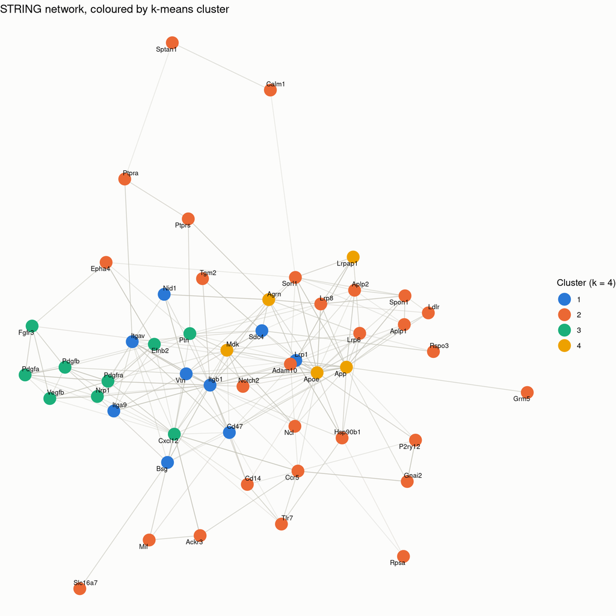

```r
for (pkg in c("igraph", "tidygraph", "ggraph", "ggrepel")) {
  if (!requireNamespace(pkg, quietly = TRUE)) install.packages(pkg)
}
library(ggraph)

cluster_palette <- c("1" = "#2a78d6", "2" = "#eb6834", "3" = "#1baf7a", "4" = "#eda100")

# Drop the "not clustered" (zero-edge) genes from the picture
net_nodes <- cluster_df %>%
  dplyr::filter(!is.na(cluster)) %>%
  left_join(mapped %>% dplyr::select(gene, STRING_id), by = "STRING_id") %>%
  mutate(cluster = factor(cluster))

net_edges <- interactions %>%
  dplyr::filter(from %in% net_nodes$STRING_id, to %in% net_nodes$STRING_id) %>%
  dplyr::select(from, to, weight = all_of(score_col))

net_graph <- tidygraph::tbl_graph(nodes = net_nodes, edges = net_edges,
                                   node_key = "STRING_id", directed = FALSE)

set.seed(1)
ggraph(net_graph, layout = "fr") +
  ggraph::geom_edge_link(ggplot2::aes(alpha = weight), colour = "#c3c2b7", show.legend = FALSE) +
  ggraph::scale_edge_alpha(range = c(0.15, 0.6)) +
  ggraph::geom_node_point(ggplot2::aes(colour = cluster), size = 7) +
  ggraph::geom_node_text(ggplot2::aes(label = gene), repel = TRUE, size = 3, colour = "#0b0b0b") +
  ggplot2::scale_colour_manual(values = cluster_palette, name = paste0("Cluster (k = ", n_clusters, ")")) +
  ggplot2::theme_void(base_size = 12) +
  ggplot2::theme(
    legend.position   = "right",
    plot.background   = ggplot2::element_rect(fill = "#fcfcfb", colour = NA),
    panel.background  = ggplot2::element_rect(fill = "#fcfcfb", colour = NA)
  ) +
  ggplot2::labs(title = "STRING network, coloured by k-means cluster")
```

```r
string_db$plot_network(mapped$STRING_id)
```

[output not shown]

## 10 Notes on interpretation

A STRING cluster hit by 2+ different `spatial_pair` analyses is a functional-association-level convergence claim: it means those genes are linked by STRING’s combined evidence (some mix of curated databases, experiments, co-expression, and text-mining), not that the original LR pairs interact directly. Same caveat as `04`’s KEGG convergence table.

**Evidence-channel robustness check:** everything above uses `score_threshold = 400` (STRING’s “medium confidence,” mixing text-mining in with harder evidence). Re-run `STRINGdb$new()` with `score_threshold = 700` (“high confidence”) to see which clusters and convergence hits survive on stronger evidence alone – a cluster that only holds together at the lower threshold is more likely inflated by text-mining co-occurrence rather than real mechanistic support.